# Analysis of m111survey Dataset

Author

Generated by Databot

Published

November 4, 2025

```r
library(bcscr)
```

**Note**

This report was generated using artificial intelligence (Claude from Anthropic) under general human direction. At the time of generation, the contents have not been comprehensively reviewed by a human analyst.

## Introduction

This report presents an analysis of the `m111survey` dataset, which appears to be survey data collected from a statistics class. The dataset contains 71 observations with 12 variables, including demographic information, lifestyle habits, and personal beliefs.

Our analysis focuses on:

1. Exploring the overall structure and characteristics of the dataset
2. Comparing driving speeds between males and females
3. Examining the relationship between GPA and fastest speed driven

## Data Exploration

```r
library(tidyverse)
```

### Dataset Structure

Let’s examine the first few rows and get an overview of the data:

```r
head(m111survey)
```

```
  height ideal_ht sleep fastest   weight_feel love_first extra_life     seat
1   76.0       78   9.5     119 1_underweight         no        yes  1_front
2   74.0       76   7.0     110 2_about_right         no        yes 2_middle
3   64.0       NA   9.0      85 2_about_right         no         no 2_middle
4   62.0       65   7.0     100 1_underweight         no         no  1_front
5   72.0       72   8.0      95 1_underweight         no        yes   3_back
6   70.8       NA  10.0     100  3_overweight         no         no  1_front
   GPA enough_Sleep    sex diff.ideal.act.
1 3.56           no   male               2
2 2.50           no   male               2
3 3.80           no female              NA
4 3.50           no female               3
5 3.20           no   male               0
6 3.10          yes   male              NA
```

```r
glimpse(m111survey)
```

```
Rows: 71
Columns: 12
$ height          <dbl> 76.00, 74.00, 64.00, 62.00, 72.00, 70.80, 70.00, 79.00…
$ ideal_ht        <dbl> 78, 76, NA, 65, 72, NA, 72, 76, 61, 67, 69, 62, 62, 75…
$ sleep           <dbl> 9.5, 7.0, 9.0, 7.0, 8.0, 10.0, 4.0, 6.0, 7.0, 7.0, 6.0…
$ fastest         <int> 119, 110, 85, 100, 95, 100, 85, 160, 90, 90, 100, 60, …
$ weight_feel     <fct> 1_underweight, 2_about_right, 2_about_right, 1_underwe…
$ love_first      <fct> no, no, no, no, no, no, no, no, no, no, no, no, yes, n…
$ extra_life      <fct> yes, yes, no, no, yes, no, yes, yes, yes, no, no, no, …
$ seat            <fct> 1_front, 2_middle, 2_middle, 1_front, 3_back, 1_front,…
$ GPA             <dbl> 3.560, 2.500, 3.800, 3.500, 3.200, 3.100, 3.680, 2.700…
$ enough_Sleep    <fct> no, no, no, no, no, yes, no, yes, no, yes, yes, yes, n…
$ sex             <fct> male, male, female, female, male, male, male, male, fe…
$ diff.ideal.act. <dbl> 2.00, 2.00, NA, 3.00, 0.00, NA, 2.00, -3.00, 2.00, 0.0…
```

### Summary Statistics

```r
summary(m111survey)
```

```
     height         ideal_ht         sleep           fastest
 Min.   :51.00   Min.   :54.00   Min.   : 2.000   Min.   : 60.0
 1st Qu.:65.00   1st Qu.:67.00   1st Qu.: 5.000   1st Qu.: 90.5
 Median :68.00   Median :68.00   Median : 7.000   Median :102.0
 Mean   :67.99   Mean   :69.95   Mean   : 6.394   Mean   :105.9
 3rd Qu.:71.75   3rd Qu.:75.00   3rd Qu.: 7.000   3rd Qu.:119.5
 Max.   :79.00   Max.   :90.00   Max.   :10.000   Max.   :190.0
                 NA's   :2
        weight_feel love_first extra_life       seat         GPA
 1_underweight: 9   no :45     no :41     1_front :27   Min.   :1.900
 2_about_right:25   yes:26     yes:30     2_middle:32   1st Qu.:2.904
 3_overweight :37                         3_back  :12   Median :3.225
                                                        Mean   :3.195
                                                        3rd Qu.:3.558
                                                        Max.   :4.000
                                                        NA's   :1
 enough_Sleep     sex     diff.ideal.act.
 no :46       female:40   Min.   :-4.000
 yes:25       male  :31   1st Qu.: 0.000
                          Median : 2.000
                          Mean   : 1.946
                          3rd Qu.: 3.000
                          Max.   :18.000
                          NA's   :2
```

**Key Observations:**

- The dataset contains 71 survey respondents
- Variables include height measurements, sleep patterns, driving behavior, weight perception, beliefs, seating preferences, GPA, and gender
- There are 40 females and 31 males
- Most respondents (46 out of 71) report not getting enough sleep
- Average sleep duration is approximately 6.4 hours
- Very few missing values overall (2 for ideal height, 1 for GPA, 2 for diff.ideal.act.)

## Gender Comparison: Fastest Speeds

One interesting question is whether males and females differ in the fastest speeds they report having driven.

### Summary Statistics by Gender

```r
speed_by_gender <- m111survey |>
  group_by(sex) |>
  summarise(
    n = n(),
    mean_speed = mean(fastest),
    median_speed = median(fastest),
    sd_speed = sd(fastest),
    min_speed = min(fastest),
    max_speed = max(fastest)
  )

speed_by_gender
```

```
# A tibble: 2 × 7
  sex        n mean_speed median_speed sd_speed min_speed max_speed
  <fct>  <int>      <dbl>        <dbl>    <dbl>     <int>     <int>
1 female    40       100.           95     17.6        60       145
2 male      31       113.          110     22.6        85       190
```

Males report driving faster on average (113.5 mph) compared to females (100 mph), a difference of approximately 13.4 mph.

### Visualization

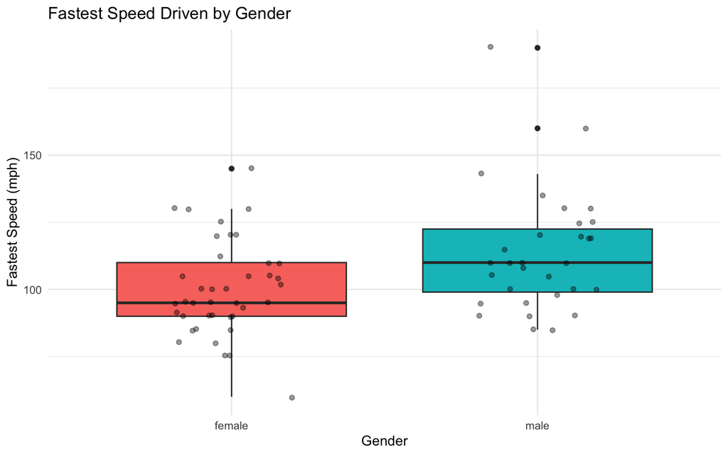

```r
ggplot(m111survey, aes(x = sex, y = fastest, fill = sex)) +
  geom_boxplot() +
  geom_jitter(width = 0.2, alpha = 0.4) +
  labs(
    title = "Fastest Speed Driven by Gender",
    x = "Gender",
    y = "Fastest Speed (mph)",
    fill = "Gender"
  ) +
  theme_minimal() +
  theme(legend.position = "none")
```

### Statistical Test

To determine if this difference is statistically significant, we perform a t-test:

```r
t_test_result <- t.test(fastest ~ sex, data = m111survey)
t_test_result
```

```
    Welch Two Sample t-test

data:  fastest by sex
t = -2.7253, df = 55.488, p-value = 0.008579
alternative hypothesis: true difference in means between group female and group male is not equal to 0
95 percent confidence interval:
 -23.254649  -3.548576
sample estimates:
mean in group female   mean in group male
            100.0500             113.4516
```

**Results:** The t-test reveals a statistically significant difference (p = 0.0086) between males and females in fastest speeds driven. The 95% confidence interval suggests the true difference is between -23.3 and -3.5 mph.

## Relationship Between GPA and Speed

We also explored whether there is any relationship between academic performance (GPA) and driving behavior (fastest speed).

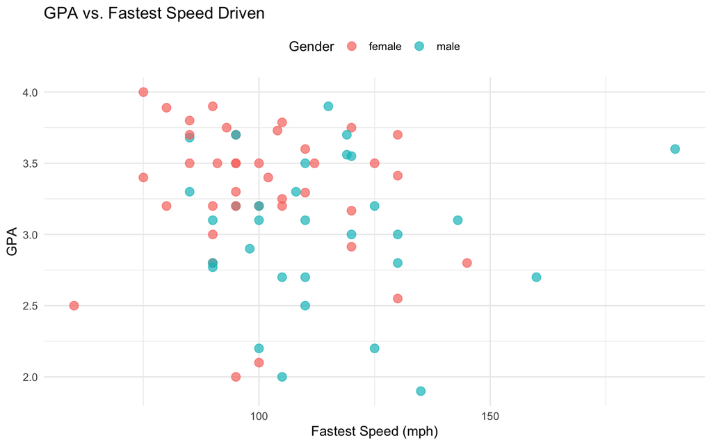

```r
ggplot(m111survey, aes(x = fastest, y = GPA, color = sex)) +
  geom_point(size = 3, alpha = 0.7) +
  labs(
    title = "GPA vs. Fastest Speed Driven",
    x = "Fastest Speed (mph)",
    y = "GPA",
    color = "Gender"
  ) +
  theme_minimal() +
  theme(legend.position = "top")
```

**Observations:**

- There is no clear linear relationship between GPA and fastest speed driven
- Female students (pink points) cluster in the lower speed range (60-145 mph)
- Male students (teal points) are spread across a wider speed range, up to 190 mph
- GPAs appear fairly evenly distributed across different speed levels for both genders
- Academic performance does not appear to be related to driving behavior in this sample

## Conclusion

This analysis of the m111survey dataset revealed several interesting findings:

1. **Gender differences in driving behavior:** Males reported significantly faster speeds than females, with a mean difference of approximately 13 mph (p = 0.0086).
2. **No relationship between GPA and speed:** There was no apparent correlation between academic performance and the fastest speed driven, suggesting these behaviors are independent in this sample.
3. **Dataset characteristics:** The survey captured a diverse range of personal characteristics and beliefs from 71 students, with minimal missing data and good representation of both genders.

Future analyses could explore other relationships in the dataset, such as the connection between sleep patterns and academic performance, or how personal beliefs correlate with other behaviors.